# Assignment 03: Anatomy of a Chart

EPPS 6356 Data Visualization | University of Texas at Dallas

Author

Muhammad Al Hasib

Published

October 13, 2026

## Part 1: Documenting murrell01.R — Anscombe’s Quartet Panel

This section documents the base R code that produces Anscombe’s Quartet as a 2×2 panel plot, explaining each line’s role in the chart’s anatomy.

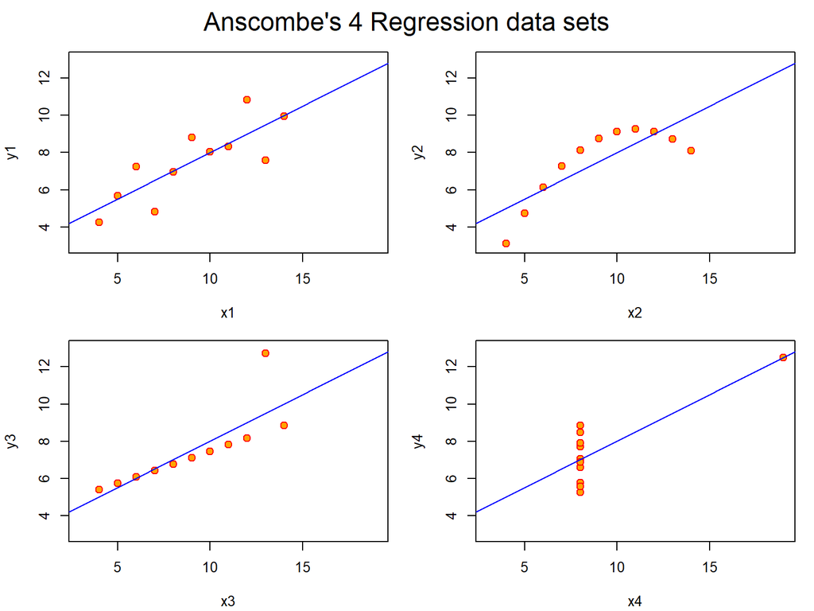

Anscombe’s Quartet — Documented Base R Panel

```r
## ── Step 1: Load the built-in dataset ────────────────────────────────────────
data(anscombe)
# R ships with Anscombe (1973)'s four paired (x, y) datasets.
# Each column is named x1–x4 and y1–y4; all 11 rows per pair.

## ── Step 2: Define a generic formula template ─────────────────────────────────
ff <- y ~ x
# A formula object. The loop below rewrites its LHS (y) and RHS (x)
# at each iteration, reusing this single object instead of writing
# four separate formulas.

## ── Step 3: Fit four OLS models with a loop ───────────────────────────────────
mods <- setNames(as.list(1:4), paste0("lm", 1:4))
# Creates a named list: list(lm1=1, lm2=2, lm3=3, lm4=4).
# setNames() assigns names so we can later call mods[["lm1"]], etc.

for (i in 1:4) {
  ff[2:3] <- lapply(paste0(c("y", "x"), i), as.name)
  # ff[2] is the response (LHS); ff[3] is the predictor (RHS).
  # paste0("y",1) → "y1"; as.name() turns the string into a symbol.
  # So ff becomes y1~x1, then y2~x2, etc.

  mods[[i]] <- lm(ff, data = anscombe)
  # Fits OLS: score = β0 + β1·x + ε for each of the four pairs.
  # The result (coefficients, residuals, fitted values) is stored in mods.
}

## ── Step 4: Set up a 2×2 plot canvas ─────────────────────────────────────────
op <- par(mfrow = c(2, 2),           # 2 rows × 2 columns of panels
          mar  = 0.1 + c(4, 4, 1, 1), # inner margins: bottom, left, top, right
          oma  = c(0, 0, 2, 0))        # outer margin: 2 lines at top for title
# par() sets global graphics parameters; op saves the old settings
# so we can restore them afterward with par(op).

## ── Step 5: Draw each scatter plot and regression line ────────────────────────
for (i in 1:4) {
  ff[2:3] <- lapply(paste0(c("y", "x"), i), as.name)
  # Rebuild the formula for this panel (same logic as Step 3).

  plot(ff, data = anscombe,
       col  = "red",     # border color of each point symbol
       pch  = 21,        # symbol: filled circle with separate border/fill
       bg   = "orange",  # fill color inside pch=21
       cex  = 1.2,       # point size (1.2× the default)
       xlim = c(3, 19),  # fixed x-axis range — identical across all 4 panels
       ylim = c(3, 13))  # fixed y-axis range — enables direct visual comparison

  abline(mods[[i]], col = "blue")
  # Draws the OLS regression line using the intercept and slope stored in mods.
  # All four lines are visually nearly identical — the key Anscombe lesson.
}

## ── Step 6: Add an outer title spanning all panels ────────────────────────────
mtext("Anscombe's 4 Regression data sets", outer = TRUE, cex = 1.5)
```

```r
# mtext() writes text in the outer margin (outer=TRUE).
# cex=1.5 makes it 1.5× larger than the default font size.

## ── Step 7: Restore original graphics parameters ──────────────────────────────
par(op)
# Resets mfrow, mar, oma to whatever they were before Step 4.
# Good practice to avoid side-effects on subsequent plots.
```

### What the code teaches

The loop pattern (`ff[2:3] <- lapply(...)`) is a compact, DRY approach to fitting and plotting multiple models without repeating nearly identical code four times. The fixed `xlim` and `ylim` across all panels is intentional: it makes the structural differences between datasets visible at a glance rather than being masked by auto-scaled axes. The outer margin title (`mtext(..., outer=TRUE)`) is a base R technique for labeling a multi-panel figure with a single call.

## Part 2: Regression Comparison Across Anscombe’s Four Datasets

This part demonstrates that identical regression statistics can hide fundamentally different data structures.

```r
## Fit all four models
data(anscombe)
ff   <- y ~ x
mods <- setNames(as.list(1:4), paste0("lm", 1:4))
for (i in 1:4) {
  ff[2:3]  <- lapply(paste0(c("y", "x"), i), as.name)
  mods[[i]] <- lm(ff, data = anscombe)
}

## Extract key statistics into a summary table
stats_list <- lapply(seq_along(mods), function(i) {
  s <- summary(mods[[i]])
  data.frame(
    Dataset     = paste0("Dataset ", i),
    Intercept   = round(coef(s)[1, 1], 3),
    Slope       = round(coef(s)[2, 1], 3),
    R_squared   = round(s$r.squared, 3),
    F_statistic = round(s$fstatistic[1], 2),
    p_value     = format.pval(pf(s$fstatistic[1], s$fstatistic[2],
                                  s$fstatistic[3], lower.tail = FALSE),
                               digits = 3)
  )
})

stats_df <- do.call(rbind, stats_list)

knitr::kable(stats_df,
             caption = "Table 1. OLS Regression Statistics — Anscombe's Quartet",
             col.names = c("Dataset", "Intercept", "Slope",
                           "R²", "F-statistic", "p-value"),
             align = "lrrrrr")
```

Table 1. OLS Regression Statistics — Anscombe’s Quartet

|  | Dataset | Intercept | Slope | R² | F-statistic | p-value |
| --- | --- | --- | --- | --- | --- | --- |
| value | Dataset 1 | 3.000 | 0.5 | 0.667 | 17.99 | 0.00217 |
| value1 | Dataset 2 | 3.001 | 0.5 | 0.666 | 17.97 | 0.00218 |
| value2 | Dataset 3 | 3.002 | 0.5 | 0.666 | 17.97 | 0.00218 |
| value3 | Dataset 4 | 3.002 | 0.5 | 0.667 | 18.00 | 0.00216 |

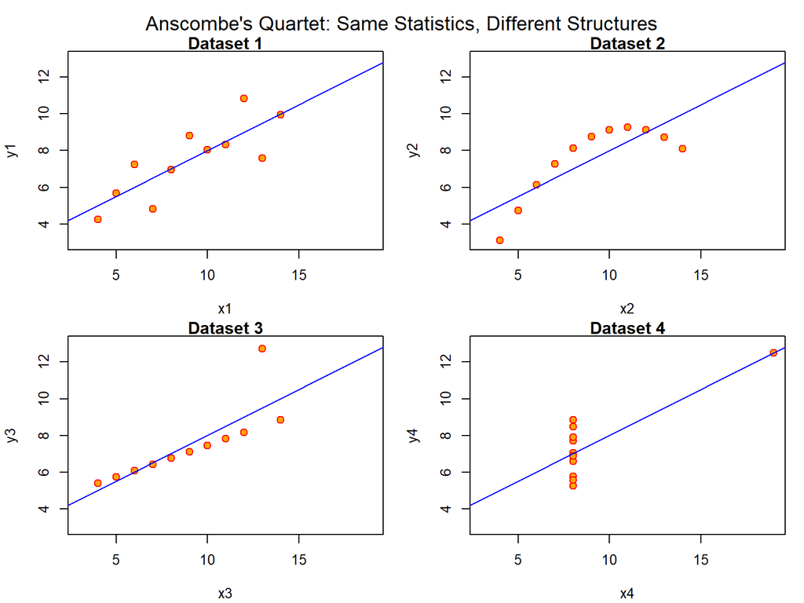

Figure 1. Anscombe’s Quartet: Identical Statistics, Different Structures

```r
op <- par(mfrow = c(2, 2), mar = 0.1 + c(4, 4, 1, 1), oma = c(0, 0, 2, 0))

for (i in 1:4) {
  ff[2:3] <- lapply(paste0(c("y", "x"), i), as.name)
  plot(ff, data = anscombe,
       col = "red", pch = 21, bg = "orange", cex = 1.2,
       xlim = c(3, 19), ylim = c(3, 13),
       main = paste("Dataset", i))
  abline(mods[[i]], col = "blue")
}

mtext("Anscombe's Quartet: Same Statistics, Different Structures",
      outer = TRUE, cex = 1.2)
```

```r
par(op)
```

### Interpretation

As Table 1 shows, all four datasets share nearly identical intercepts (~3.00), slopes (~0.50), R² values (~0.667), and p-values (~0.002). Yet Figure 1 reveals entirely different structures: Dataset I is a clean linear relationship; Dataset II follows a quadratic curve; Dataset III is linear with a single influential outlier; Dataset IV has a degenerate x distribution with one leverage point. This is the central lesson of Anscombe’s Quartet — summary statistics must never substitute for visual inspection.

## Part 3: Base R Fine-Tuning

This part applies typographic and aesthetic refinements to the Anscombe panel using base R’s graphics parameters.

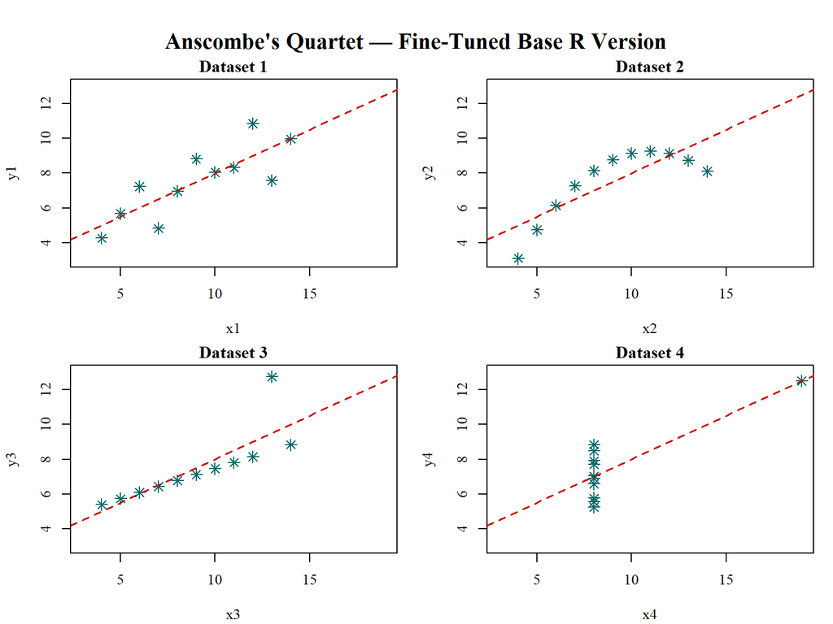

Figure 2. Fine-Tuned Anscombe Panel (Serif Font, Custom Colors, Star Symbol)

```r
data(anscombe)
ff   <- y ~ x
mods <- setNames(as.list(1:4), paste0("lm", 1:4))
for (i in 1:4) {
  ff[2:3]  <- lapply(paste0(c("y", "x"), i), as.name)
  mods[[i]] <- lm(ff, data = anscombe)
}

## Fine-tuning parameters
op <- par(
  mfrow  = c(2, 2),
  mar    = 0.1 + c(4, 4, 1.5, 1),
  oma    = c(0, 0, 3, 0),
  family = "serif"          # serif font throughout (Times-style)
)

for (i in 1:4) {
  ff[2:3] <- lapply(paste0(c("y", "x"), i), as.name)

  plot(ff, data = anscombe,
       col  = "#006666",    # teal border for points
       pch  = 8,            # asterisk / star symbol
       cex  = 1.3,
       xlim = c(3, 19),
       ylim = c(3, 13),
       main = paste("Dataset", i),
       xlab = paste0("x", i),
       ylab = paste0("y", i))

  abline(mods[[i]],
         col = "#CC0000",   # crimson regression line
         lty = 2,           # dashed line style
         lwd = 1.8)
}

mtext("Anscombe's Quartet — Fine-Tuned Base R Version",
      outer = TRUE, cex = 1.3, font = 2)   # font=2 → bold
```

```r
par(op)
```

### Fine-Tuning Choices

| Parameter | Value | Effect |
| --- | --- | --- |
| `family = "serif"` | `"serif"` | Times-style font for academic publication look |
| `pch` | `8` | Star/asterisk symbol — distinctive, not the default circle |
| `col` | `"#006666"` | Teal — distinct from regression line, colorblind-safe |
| `abline col` | `"#CC0000"` | Crimson — high contrast against teal points |
| `lty` | `2` | Dashed line — visually separates fit line from data |
| `lwd` | `1.8` | Slightly thicker line for legibility |

## Part 4: ggplot2 Reproduction

This part reproduces the fine-tuned Anscombe panel using ggplot2, and documents the mapping from base R to ggplot2 grammar.

[figure not shown]

Figure 3. ggplot2 Reproduction of the Fine-Tuned Anscombe Panel

```r
library(tidyverse)

## Reshape Anscombe to long format for ggplot2
data(anscombe)

anscombe_long <- data.frame(
  dataset = rep(1:4, each = 11),
  x = c(anscombe$x1, anscombe$x2, anscombe$x3, anscombe$x4),
  y = c(anscombe$y1, anscombe$y2, anscombe$y3, anscombe$y4)
)

## Build the faceted plot
ggplot(anscombe_long, aes(x = x, y = y)) +

  # Points — teal, star shape (shape=8)
  geom_point(color = "#006666", shape = 8, size = 2.5) +

  # Regression line — crimson, dashed
  geom_smooth(method = "lm", se = FALSE,
              color = "#CC0000", linetype = "dashed", linewidth = 0.9) +

  # One panel per dataset
  facet_wrap(~ paste("Dataset", dataset), nrow = 2) +

  # Axis limits matching base R version
  coord_cartesian(xlim = c(3, 19), ylim = c(3, 13)) +

  # Titles and labels
  labs(
    title    = "Anscombe's Quartet — ggplot2 Reproduction",
    subtitle = "Identical regression statistics; visually distinct structures",
    x = "x",
    y = "y"
  ) +

  # Theme matching the serif, clean academic style
  theme_bw(base_family = "serif") +
  theme(
    plot.title    = element_text(face = "bold", size = 13),
    plot.subtitle = element_text(size = 10, color = "grey40"),
    strip.text    = element_text(face = "bold"),
    panel.grid.minor = element_blank()
  )
```

### Base R → ggplot2 Mapping

| Base R | ggplot2 Equivalent | Notes |
| --- | --- | --- |
| `plot(ff, data=anscombe, col=..., pch=8)` | `geom_point(color=..., shape=8)` | Data layer |
| `abline(mod, col=..., lty=2)` | `geom_smooth(method="lm", linetype="dashed")` | Fit layer |
| `par(mfrow=c(2,2))` | `facet_wrap(~dataset, nrow=2)` | Panel layout |
| `xlim=`, `ylim=` | `coord_cartesian(xlim=, ylim=)` | Axis limits |
| `mtext(..., outer=TRUE)` | `labs(title=...)` | Figure title |
| `par(family="serif")` | `theme_bw(base_family="serif")` | Typography |
| `abline col="#CC0000"` | `geom_smooth(color="#CC0000")` | Line color |

## Part 5: COVID-19 Daily Deaths in Europe — Replication

This part replicates a chart of COVID-19 daily deaths in Europe using Our World in Data, following the style of the reference visualization: one point per country-day, colored in deep pink, with country labels on outlier peaks.

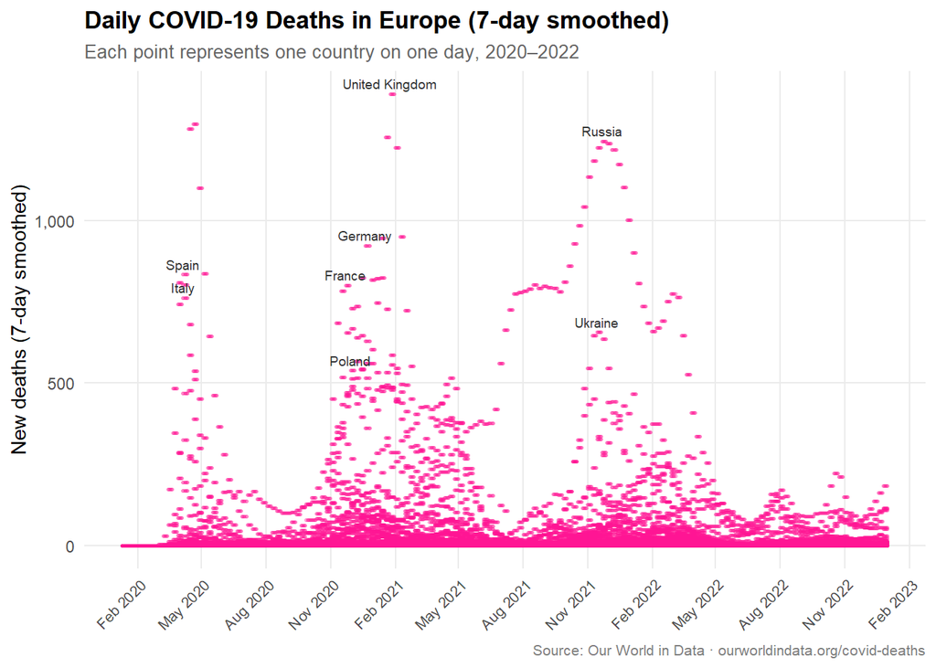

```r
library(tidyverse)

## ── Download OWID COVID data ──────────────────────────────────────────────────
## Source: https://ourworldindata.org/covid-deaths
## File:   https://raw.githubusercontent.com/owid/covid-19-data/master/public/data/owid-covid-data.csv

covid_url <- "https://raw.githubusercontent.com/owid/covid-19-data/master/public/data/owid-covid-data.csv"

## Read directly from URL (requires internet)
covid_raw <- tryCatch(
  read_csv(covid_url,
           col_types = cols(
             iso_code          = col_character(),
             continent         = col_character(),
             location          = col_character(),
             date              = col_date(format = "%Y-%m-%d"),
             new_deaths        = col_double(),
             new_deaths_smoothed = col_double(),
             .default          = col_skip()
           ),
           show_col_types = FALSE),
  error = function(e) NULL
)

if (!is.null(covid_raw)) {

  ## Filter to European countries, 2020-2022
  europe_deaths <- covid_raw %>%
    filter(
      continent == "Europe",
      !is.na(new_deaths_smoothed),
      date >= as.Date("2020-01-01"),
      date <= as.Date("2022-12-31")
    ) %>%
    select(location, date, new_deaths_smoothed)

  ## Identify peak observations per country for labeling
  country_peaks <- europe_deaths %>%
    group_by(location) %>%
    slice_max(new_deaths_smoothed, n = 1) %>%
    ungroup() %>%
    filter(new_deaths_smoothed > 500)   # only label prominent peaks

  ## ── Plot ──────────────────────────────────────────────────────────────────
  ggplot(europe_deaths, aes(x = date, y = new_deaths_smoothed)) +

    geom_point(color = "#FF1493", alpha = 0.25, size = 0.6) +

    geom_text(data = country_peaks,
              aes(label = location),
              size = 2.5, vjust = -0.5, hjust = 0.5,
              color = "grey20", check_overlap = TRUE) +

    scale_x_date(date_breaks = "3 months", date_labels = "%b %Y") +
    scale_y_continuous(labels = scales::comma) +

    labs(
      title    = "Daily COVID-19 Deaths in Europe (7-day smoothed)",
      subtitle = "Each point represents one country on one day, 2020–2022",
      x        = NULL,
      y        = "New deaths (7-day smoothed)",
      caption  = "Source: Our World in Data · ourworldindata.org/covid-deaths"
    ) +

    theme_minimal(base_family = "sans") +
    theme(
      plot.title      = element_text(face = "bold", size = 13),
      plot.subtitle   = element_text(size = 10, color = "grey40"),
      plot.caption    = element_text(size = 8, color = "grey50"),
      axis.text.x     = element_text(angle = 45, hjust = 1, size = 8),
      panel.grid.minor = element_blank()
    )

} else {
  message("Could not download OWID data. Please run this chunk with internet access.")
}
```

### Design Notes

The chart uses `geom_point()` with `alpha = 0.25` to handle overplotting — many countries overlap in time, so transparency reveals the density of the distribution without hiding individual observations. The color `#FF1493` (deep pink) provides high contrast against the white background while evoking the urgency of the subject. Country labels are placed only on the most prominent peaks (`new_deaths_smoothed > 500`) to avoid clutter, following Yau’s (2011) principle of labeling only what the reader needs to orient themselves. The 7-day smoothed series (rather than raw daily counts) removes weekend-reporting artifacts that would otherwise dominate the visual.

## References

Anscombe, F. J. (1973). Graphs in statistical analysis. *The American Statistician, 27*(1), 17–21.

Murrell, P. (2011). *R graphics* (2nd ed.). CRC Press.

Our World in Data. (2024). *COVID-19 dataset*. https://ourworldindata.org/covid-deaths

Wilkinson, L. (2005). *The grammar of graphics* (2nd ed.). Springer.

Yau, N. (2011). *Visualize this: The FlowingData guide to design, visualization, and statistics.* Wiley.